# Introduction to Data Visualisation - RStudio

### Tidying Up Other Elements

#### Plot Theme

The plot theme is another important aesthetic feature. There are several existing themes in the `ggplot2` library.

```r
# classic

ggplot(data) +
  geom_bar(mapping = aes(x = cut, fill = clarity)) +
  theme_classic()

# minimal

ggplot(data) +
  geom_bar(mapping = aes(x = cut, fill = clarity)) +
  theme_minimal()

# dark

ggplot(data) +
  geom_bar(mapping = aes(x = cut, fill = clarity)) +
  theme_dark()
```

#### Create Theme to Standardise Plot Aesthetic

ggplot axis label text size quite small by default We can edit this using the `theme` command

```r
# create your own theme

my_theme <-
  theme_classic(base_size = 15) + # change the base size of text
  theme(
    axis.title = element_text(size = rel(1.05)), # adjust the relative size of axis text
    legend.title = element_text(size = rel(1.05)), # adjust the relative size of the legend text
    plot.title = element_text(hjust = 0.5))  # centre the title (Horizontal alignment: 0 = left, 0.5 = center, 1 = right)

# apply theme to a plot

ggplot(data) +
  geom_bar(mapping = aes(x = cut, fill = clarity)) +
  ggtitle("Cut and Clarity of Diamonds") +
  my_theme
```

Axis labels can be modified using the `labs` command.

```r
# labels can be amended with the `labs` argument

ggplot(data) +
  geom_bar(mapping = aes(x = cut, fill = clarity)) +
  ggtitle("Cut and Clarity of Diamonds") +
  labs(x = "\nCut", y = "Frequency\n") +
  my_theme
```

Notice the use of the newline `\n` command to space out the axis labels better.

## Examples of other plot types

I have given you the tools for building tidy bar-plots. However, there are many other types of plot. Let’s stick to the `diamonds` dataset and try some others for fun.

### Jitter Plot of Diamonds Cut and Clarity

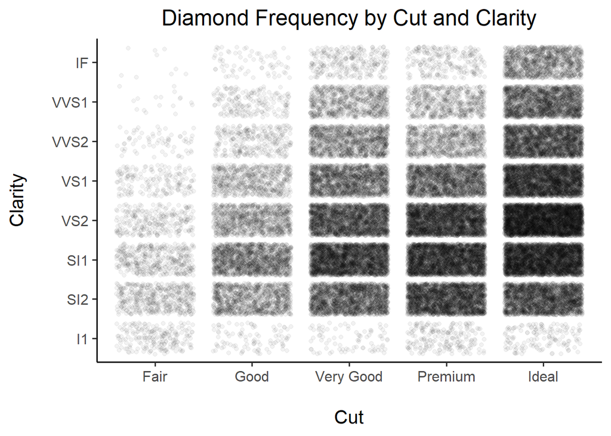

```r
ggplot(data, aes(cut, y = clarity)) +
  geom_jitter(alpha = 0.05) +
  labs(title = "Diamond Frequency by Cut and Clarity",
       x = "\nCut",
       y = "Clarity\n") +
  my_theme
```

`geom_jitter` generates a dotplot that “jitters” the points by adding statistical noise. This makes it easier to compare counts between all combinations of two variables (in our case `cut` and `clarity`).

### Diamond data Boxplots

Boxplots can also be used to examine the relationship between the diamonds price cut and quality. As this plot will include 3 variables it can be said to be multivariate.

I’ve assigned the plot to an object first to apply a new colour scheme with the RColourBrewer package.

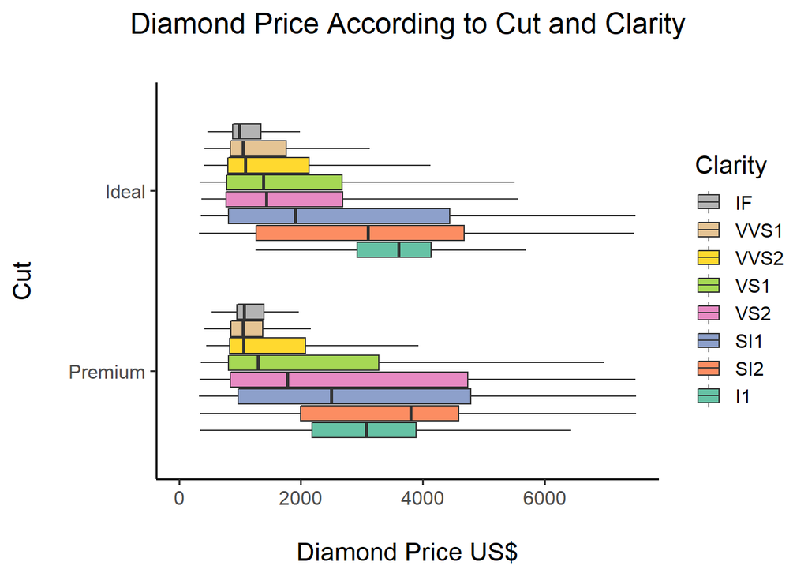

```r
bp <-
  data %>%
  dplyr::filter(cut %in% c("Premium", "Ideal")) %>% # let's take a look at Premium and Ideal cuts spcifically
  ggplot(., aes(factor(cut), price, fill=clarity)) +
  geom_boxplot(outlier.shape = NA) + # do not plot outliers
  ggtitle("Diamond Price According to Cut and Clarity\n") +
  labs(x = "Cut\n", y = "\nDiamond Price US$") +
  ylim(0,7500) +
  coord_flip() # flip the plot 90 degrees clockwise



bp +
  my_theme +
  scale_fill_brewer(palette="Set2") +
  guides(fill = guide_legend(title = "Clarity", # rename the legend
                             reverse = TRUE)) # reverse the order of the legend items
```

### Plotting Relationships using Facet

```r
bf <-
  data %>%
  dplyr::filter(cut %in% c("Premium", "Ideal"),
                color %in% c("D", "E", "J")) %>% # let's take a look at Premium and Ideal cuts spcifically
  ggplot(., aes(factor(cut), price, fill=clarity)) +
  geom_boxplot() +
  ggtitle("Diamond Price According to Colour, Clarity and Cut\n") +
  labs(x = "Cut\n", y = "\nDiamond Price U$") +
  ylim(0,7500) +
  coord_flip() + # flip the plot 90 degrees clockwise
  facet_grid(cols = vars(color))


bf +
  my_theme +
  scale_fill_brewer(palette="Set2") +
  guides(fill = guide_legend(title = "Clarity",
                             reverse = TRUE)) +
  theme(axis.text.x = element_text(angle = 30, hjust = 1, vjust = 1)) # adjust x-axis text angle
```

### Creating an Interactive Plot using `plotly`

The `plotly` package allows us to add levels of interactivity to our visualisations such as subsetting displays by selecting variable levels.

```r
bp <-
  ggplot(data) +
  geom_bar(mapping = aes(x = cut, fill = clarity)) +
  ggtitle("Cut and Clarity of Diamonds") +
  labs(x = "\nCut", y = "Frequency\n") +
  my_theme

ggplotly(bp) # create interactve version of plot
```

# Summary

- RStudio is a great tool for learning about data visualisation.
- There are datasets in the `tidyverse` package ideal for deploying visualisation techniques, creating exercises, and assessments.
- Today, I’ve scratched the surface of what is possible, and hopefully whet your data vis appetites!
- There are plenty of free online resources dedicated to plotting in RStudio.

# Additional resources

[R Graphics Cookbook, 2nd edition](https://r-graphics.org/index.html) – very useful starting guide for ggplot2

[R for Data Science](http://r4ds.had.co.nz/) – useful for learning *Tidyverse* syntax

[Bookdown Chapter on Data Visualisation](https://bookdown.org/mikemahoney218/IDEAR/visualizing-your-data.html)